# When One Thing Depends on Another; Conditional Probability

Steve Elston

09/15/2022

# Introduction

Many real-world random variables depend on other random variables

- Statistical models of complex processes invariably require the use of **conditional probability distributions**
- **Conditional probability** is the probability that event A occurs given that event B has occurred
- Write the conditional probability of A given B as:

$$P(A|B)$$

- **Example:** Model of the probability of contracting the infectious disease, depends on other variables
  - In more technical terms, the probability of contracting the disease is **conditional** on other random variables.
  - Age, contact with people carrying the disease, immunity, etc.

# Properties of Conditional Probability

Example:

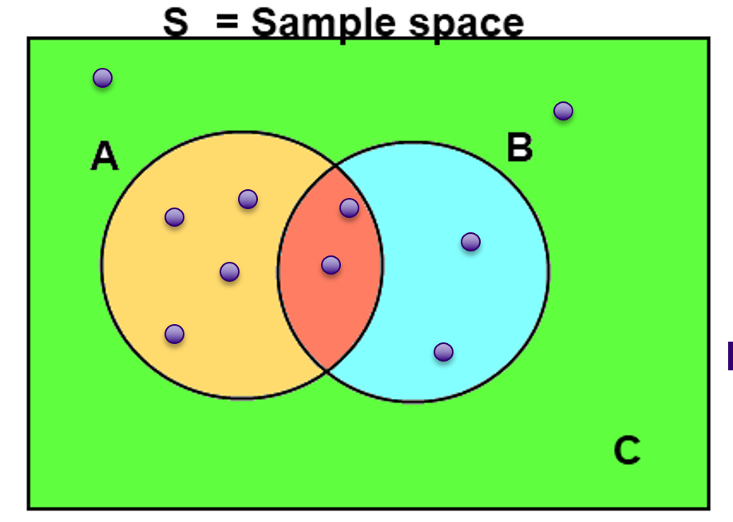

Example of conditional probability of discrete events; credit, Wikipedia commons

- **Sample space** is the space of all possible events in the set $S$
- Sample space is divided into several **subspaces** or **subsets**, $A$, $B$ and $C$
- **Intersection** is where the two sets overlap occur in both $A$ and $B$

# Properties of Conditional Probability

Example:

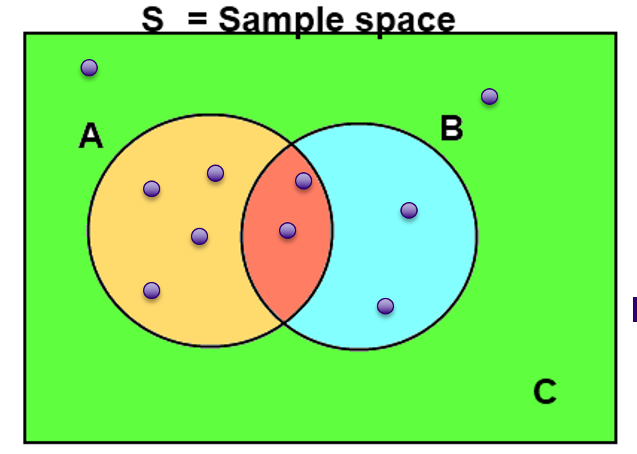

Example of conditional probability of discrete events; credit, Wikipedia commons

- **Intersection** is where the two sets overlap occur in both $A$ and $B$
  - First, find the relationship between conditional probability and the intersection between the sets, $P(A \cap B)$
  - The probability of the intersection is the product of two probabilities:
  1. $P(B)$ since B must be true to be in this intersection.
  2. $P(A|B)$ since A must also occur when B is occurring
  - The result is:

$$P(A \cap B) = P(A|B) P(B)$$

# Properties of Conditional Probability

$$P(A \cap B) = P(A|B) P(B)$$

Rearranging terms we get the following:

$$\begin{align}
P(A|B) &= \frac{P(A \cap B)}{P(B)} \\
& = \frac{\frac{2}{10}}{\frac{4}{10}} = \frac{2}{4} = \frac{1}{2}
\end{align}$$

We could have, just as well, written the last equation as:

$$P(B \cap A) = P(B|A)P(A)$$

Now, the probability of an identical event in the same intersection:

$$P(A \cap B) = P(A|B) P(B) = P(B|A)P(A) =
P(B \cap A)$$

**Factorization** of a probability function is a key tool: notice that the factorization of a conditional probability distribution in not unique

# Set Operations and Probability

Set operations are applied to probability problems

1. **Intersection:**

$$P(A \cap B) = P(A|B)P(B)$$

2. **Union:** is the sum of the probabilities of the sets minus the intersection between the sets:

$$P(A \cup B) = P(A) + P(B) - P(A \cap
B)$$

3. **Negation:** Example, compute the probability of an event being in subset $A$ but not in $B$:

$$P(A\ and\ \neg B) = P(A) - P(B \cap
A)$$

**Example:** We can apply **[De Morgan’s Laws](https://en.wikipedia.org/wiki/De_Morgan%27s_laws)**:

$$\begin{align}
P(\neg (A \cup B)) &= P(\neg A\ \cap \neg B)\\
P(\neg (A \cap B)) &= P(\neg A\ \cup \neg B)
\end{align}$$

# Independence and Mutual Exclusivity

The factorization of probability distributions can be simplified if events are either **independent** or **mutually exclusive**

- At first glance, these concepts may seem similar
  - Are quite different
  - Very different implications
- **Independence** of sets $A$ and $B$ means the occurrence of an event in $A$, does not have any dependency on an event in $B$
- **Mutual exclusivity** means events cannot occur in both the sets $A$ and $B$

# Independence

Express independence of random variables, $A \perp B$, mathematically:

$$\begin{align}
P(A\ \cap B) &= P(A|B)P(B) = P(A)P(B)\\
P(A\ \cup B) &= P(A) + P(B) - P(A)P(B)\\
P(A|B) &= P(A)\\
P(A| \neg B) &= P(A)
\end{align}$$

But independence of A given B does not imply independence of B given A:

$$P(A|B) = P(A) \nLeftrightarrow P(B|A) =
P(B)$$

In other words, we need to pay attention to if A is independent of B or B is independent of A  
- One or the other could be true - Both could be true

# Mutual Exclusivity

If the intersection between events is an empty set:

$$A \cap B = \emptyset$$

Then, events in A are **mutually exclusive** of events in B:

$$\begin{align}
P(A \cup B) &= P(A) + P(B)\\
P(A|B) &= 0\\
P(A| \neg B) &= \frac{P(A)}{1 - P(B)}
\end{align}$$

And, $A$ mutually exclusive of B, implies B is mutually exclusive of A

# Conditional Distributions and Bayes’ Theorem

**Bayes’ theorem**, also known as **Bayes’ rule**, is a powerful tool to think about and analyze conditional probabilities

- We can derive Bayes Theorem starting with the following relationships:

$$P(A \cap B) = P(A|B)P(B)\\
P(B \cap A) = P(B|A)P(A)$$

- Now:

$$P(A \cap B) = P(B \cap A)$$

- Which leads to:

$$\begin{align}
P(A|B)P(B) &= P(B|A)P(A)\\
P(A|B) &= \frac{P(B|A)P(A)}{P(B)}
\end{align}$$

Which is Bayes’ theorem!

# Interpreting Bayes Theorem

How can we interpret Bayes’ theorem in a useful way?

- Consider an example using Bayes Theorem for an hypothesis test given some data or **evidence**
- We must make an assertion of our prior probability that the hypothesis is true

$$prior(hypothesis)$$

- We also must choose a likelihood function of the evidence given the hypothesis

$$Likelihood(evidence\ |\
hypothesis)$$

# Interpreting Bayes Theorem

Now, we can think of Bayes’ theorem in the following terms:

$$Posterior(hypothesis\ |\ evidence) =
\frac{Likelihood(evidence\ |\ hypothesis)\
prior(hypothesis)}{P(evidence)}$$

- We discuss selection of prior probability distributions and likelihood functions in subsequent lectures
- The denominator $P(evidence)$ or **partition function** is problematic
- Required to normalize the posterior distribution to range $0 \le Posterior(hypothesis\ |\ evidence) \le 1$

# Interpreting Bayes Theorem

Denominator must account for all possible outcomes, or alternative hypotheses, $h'$:

$$Posterior(hypothesis\ |\ evidence) =\\
\frac{Likelihood(evidence\ |\ hypothesis)\ prior(hypothesis)}{\sum_{
h' \in\ All\ possible\ hypotheses}Likelihood(evidence\ |\ h')\
prior(h')}$$

This is a formidable problem!

# Bayes Theorem Example

Hemophilia is a serious genetic condition expressed on any X chromosome

- Women have two X chromosomes and are unlikely to exhibit hemophilia
  - One X chromosome inherited from each parent
  - Must inherit hemophilia from both parents
- Men have one X chromosome and one Y chromosome
  - Inherit Y chromosome from the father
  - Inherit X chromosome, and possibly hemophilia, from the mother
- Say a woman has a brother who exhibits hemophilia
  - X chromosome expression is $\theta = 1.0$ - brother has hemophilia with $P = 1.0$
  - Woman’s father does not exhibit hemophilia, $\theta = 0$ - father has hemophilia with $P = 0.0$
  - Our prior probability that she carries the genetic marker for hemophilia $\theta = 0.5$ - Woman’s X chromosome has P = 0.5 that it is from mother, who carried the marker with $P = 1.0$

# Bayes Theorem Example

As evidence the woman has two sons (not identical twins) with no expression of hemophilia

- What is the likelihood for the two sons $X = (x_1,x_2)$ not having hemophilia?
- Two possible cases here
  - Case where woman caries one X chromosome with hemophilia expression, $\theta = 1$, and probability of passing to son = 0.5
  - Case where woman does not carry an X chromosome with hemophilia expression, $\theta = 0$

$$p(x_1=0, x_2=0 | \theta = 1) = 0.5 * 0.5 = 0.25 \\
p(x_1=0, x_2=0 | \theta = 0) = 1.0 * 1.0 = 1.0$$

Note: we are neglecting the possibility of a mutations in one of the sons

# Bayes Theorem Example

Use Bayes theorem to compute probability woman carries an X chromosome with hemophilia expression, $\theta = 1$

$$p(\theta=1 | X) = \frac{p(X|\theta=1) p(\theta=1)}{p(X|\theta=1)
p(\theta=1) + p(X|\theta=0) p(\theta=0)} \\
= \frac{0.25 * 0.5}{0.25 * 0.5 + 1.0 * 0.5} = 0.20$$
Where:
$$\begin{align}
Likelihood &= p(X|\theta=1) = 0.5 0.5 = 0.25\\
Prior\ probability &= p(\theta=1) = 0.5\\
Probability\ of\ hypothesis\ no\ marker &= p(\theta=0) = 1 -
p(\theta=1) = 0.5
\end{align}$$

The **evidence** of two sons without hemophilia causes us to update our **belief** that the probability of the woman carrying the disease

# Marginal Distributions

In many cases we are interested in the **marginal distribution**

- Example, it is often the case that only one or a few parameters of a joint distribution will be of interest
  - In other words, we are interested in the marginal distribution of these parameters
  - The denominator of Bayes theorem, $P(data)$, can be computed as a marginal distribution
- Consider a multivariate probability density function with $n$ variables, $p(\theta_1, \theta_2, \ldots, \theta_n)$
  - **Marginal distribution** is the distribution of one variable with the others integrated out.
  - Integrate over all other variables $\{ \theta_2, \ldots, \theta_n \}$ the result is the marginal distribution, $p(\theta_1)$:

$$p(\theta_1) = \int_{\theta_2, \ldots,
\theta_n} p(\theta_1, \theta_2, \ldots, \theta_n)\ d\theta2, \ldots, d
\theta_n$$

- For discrete distribution the above is a summation
  $$p(\theta_1) = \sum_{\theta_2, \ldots, \theta_n}
  p(\theta_1, \theta_2, \ldots, \theta_n)$$

# Example: Marginal Distribution

**Marginal distributions** of multivariate Normal with $\mu = [0,0]$ and $\sigma = \begin{bmatrix} 1.0 & 0.0 \\ 0.0 & 1.0 \end{bmatrix}$

Marginal distributions **displayed on margins** of scatter plot

```
## For x mean = 0.014143391305686877  variance = 0.9422459154327474
## For y mean = -0.030639573892598113  variance = 0.9834781862781161
```

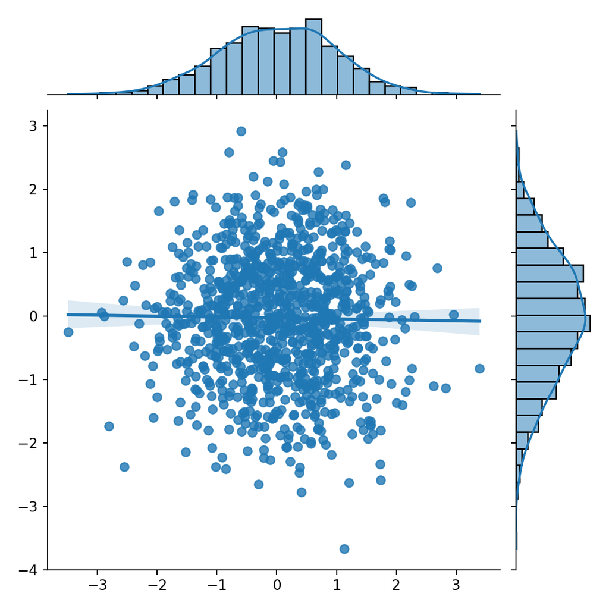

# Example: Marginal Distribution

**Marginal distributions** of multivariate Normal with $\mu = [0,0]$ and $\sigma = \begin{bmatrix} 1.0 & 0.5 \\ 0.5 & 1.0 \end{bmatrix}$

Marginal distributions **displayed on margins** of scatter plot

```
## For x mean = -0.03097095972118977  variance = 0.9515116745292175
## For y mean = -0.0618435252254139  variance = 1.0206970889966356
```

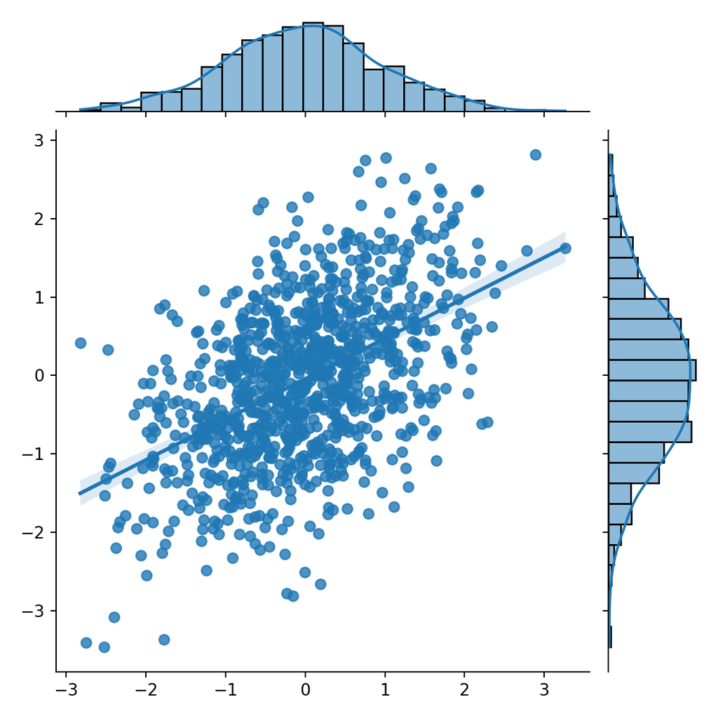

# Example: Marginal Distribution

**Marginal distributions** of multivariate Normal with $\mu = [0,0]$ and $\sigma = \begin{bmatrix} 1.0 & 0.9 \\ 0.9 & 1.0 \end{bmatrix}$

Marginal distributions **displayed on margins** of scatter plot

```
## For x mean = -0.03902993462783489  variance = 0.9970254226866206
## For y mean = -0.06192143862563938  variance = 0.9812738103164559
```

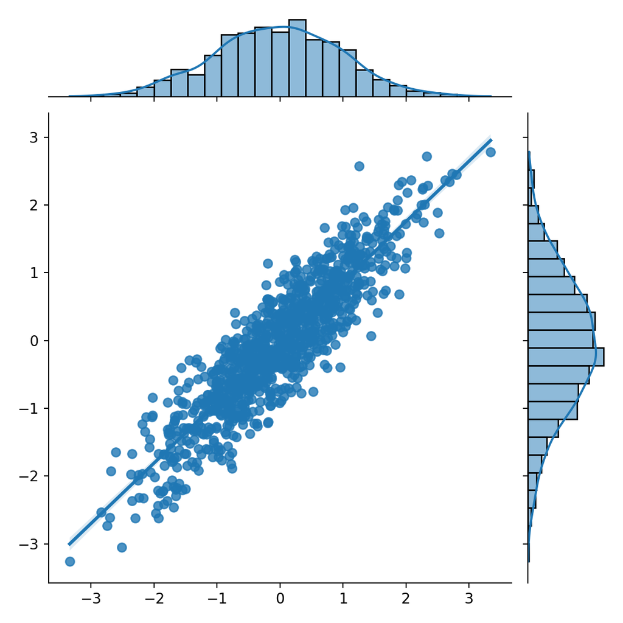

# Conditional Probability Example

A simple and widely used example of using conditional probabilities to work out the chance of having a rare disease.

- Sickle Cell Anemia is a serious, but fairly rare, disease
- The probability that a given patient, drawn at random from the population of all people in the United States, has the disease is $P(S) = \frac{1}{3200} = 0.0003125$. We can describe the possible events in diagnosing this condition as:
  - $S \Rightarrow$ a patient has the disease.
  - $S' \Rightarrow$ a patient does not have the disease.
  - $\oplus \Rightarrow$ patient tests positive.
  - $- \Rightarrow$ a patient tests negative.

# Conditional Probability Example

What if a medical company claims that it has developed a test that is 99% accurate?

- We can write:
  - $P(S |\oplus) = 0.99$
  - $P(S'|-) = 0.99$
- On the surface, it seems that a 99% reliable test is rather good
  - On average, 99 people out of 100 who have the disease will be identified and treated
  - But, dig into the conditional probabilities and make sure!

# Conditional Probability Example

From the root the **directed acyclic graphical model (DAG)** defines a conditional dependency structure

- Goal: Evaluate the medical test as a **decision rule** for treatment
- Summarize the conditional probabilities for these outcomes:
  - $P(\oplus | S)$: Conditional probability the test correctly identifies patient with disease
  - $P(- | S)$: Conditional probability of a negative test for a patient with the disease; **Type II Error** or **False Negative**
  - $P(\oplus | S')$: Conditional probability that a patient with no disease tests positive; **Type I Error** or **False Positive**
  - $P(- | S')$: Conditional probability of a negative test for a patient with no disease

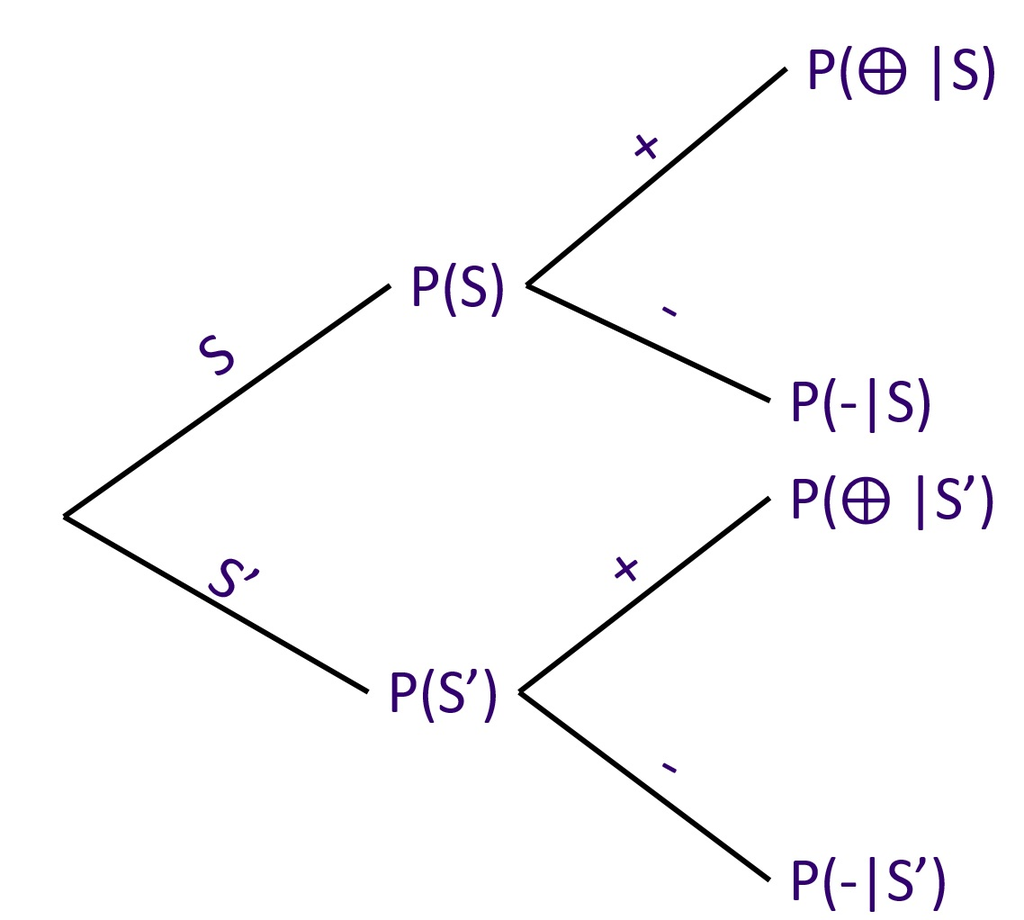

Graph showing dependency of conditional distribution

# Conditional Probability Example

Four possible outcomes shown using a **confusion matrix** or **truth table**

- Table shows conditional probabilities of each outcome

|  | Positive Test | Negative Test |
| --- | --- | --- |
| **Disease** | True Positive Rate | False Negative Rate |
| **No Disease** | False Positive Rate | True Negative Rate |

- **Tip:** Make sure the numbers in your confusion matrix sum to 1.0

# Summary

# Summary

- Bayes’ theorem
  $$P(A|B) =
  \frac{P(B|A)P(A)}{P(B)}$$
- Marginal distribution

$$p(\theta_1) = \int_{\theta_2, \ldots, \theta_n} p(\theta_1, \theta_2,
\ldots, \theta_n)\ d\theta2, \ldots, d \theta_n\\$$

$$p(\theta_1) = \sum_{\theta_2, \ldots, \theta_n} p(\theta_1, \theta_2,
\ldots, \theta_n)$$